# Unit 3 Intro to R 作業總評

2021/10/20

> 總評初稿，傳送個人回饋單之後更新。

## 作業評分總原則

從這次的總評表開始，第一部分是總原則說明，讓同學了解教練與助教評分的方式。單元3在幾乎空白的Rmd檔案演練，引導同學認識Rmarkdown的構成。Rmarkdown的編輯指引可參考[速查表](https://rstat-project.github.io/Reproducible_STAT/cheatsheets/rmarkdown-2.0-TC.pdf)，提供需要指引的同學隨時參考。

### 準時推送(OT)

單元3因為遇到連假，截止日期時間延後到2021/10/12 14:00:00。根據Assignment.html更新的日期時間決定，教練有寫R code，用來檢測各位同學的作業repo裡有沒有Assignment.html？Assignment.html的日期時間有沒有超過繳交期限？如果有作業網頁且未逾時，OT評分就是“非常厲害”；如果過了繳交期限，從這個單元開始，OT評分就是“需要加把勁”，過了下一次上課開始時間，就沒有評分了。

### 演練充分度(OC)

為激勵同學使用Rmarkdown演練程式碼寫作及紀錄一般筆記，單元2開始會要求同學務必上傳有完整開頭的Assignment.html。單元3上課一開始就有說明，了解如何製作有完整開頭的Assignment.html。另一方面，繳交的作業缺少Assignment.html，就沒有OC評分了。

因為大部分演練項目都會是在上課時完成，如果Assignment.html並沒有呈現這些項目的演練成果，但是有嘗試做課後演練項目，代表你上課時可能沒有跟上示範，課後並沒有嘗試加強學習，你的作業OC評分會是“需要加把勁”。

**請注意！**如果上課 時未完成演練項目，課後也一定要補上。如果只做課後演練項目，評分也是“需要加把勁”。

每個單元會有幾個項目是主要演練項目，主要演練項目的回答是用來評估你的OC評分是“還算可以”、“相當不錯”、還是“非常厲害”。如果每個演練項目你都有提出回答，但是主要演練項目的回答不夠完整，OC評分會你的整份作業答題狀況，得到“還算可以”或“相當不錯”，差異在於教練和助教都覺得你的主要演練項目可以改進的比例超過一半，就會是“還算可以”。如果所有演練項目都有做，主要演練項目有達到教練認可的標準，OC評分就是“非常厲害”。

### 演練活用度(EO)

EO評分以點數計算，計算方式目前有以下幾種：

- 回覆討論區的單元討論貼文

以下是出現在討論區，每個單元討論貼文的固定置頂內容。

```
歡迎分享你學習這個單元時發現的問題 (😄)
還有你認為有助學習這個單元的任何資訊或技巧 (🎉)
留意上課會出現意外的限量搶答(👍)

教練給予以上任何一種表情符號，均列入演練活用度評分。
```

由於表情符號是unicode字符的一種，教練能直接運用網頁搜尋計算次數，獲得任何一種表情符號，計一次EO點數。

作業演練項目有標記**活用**的項目，請將成果回覆到單元討論區帖子，方便教練和助教清點。

- 分享運用心得

在討論區以“💡Ideas”張貼心得文，說明使用那些單元的技巧或觀念解決問題。

- 分享學習問題

在討論區以“🙏Q&A”張貼問題，說明你遇到的技巧或觀念問題。回覆者的回答有助解決問題，可獲得🎉 。

不論是那種狀況，一個單元每位同學可獲得的EO點數上限是4點。複數單元的心得或學習問題，請自行指定要計入那個單元作業評分。

## 單元3學習重點與建議

單元3的設計是引導同學認識Rmarkdown的基本編輯與運用方法，以及啟發自我學習R程式寫作的能力。不同於多數程式設計課程，psyteachr的教學哲學是**與其送你好吃的雞排，不如教你如何製作與銷售好吃雞排**，所以單元3的作業檔案設計是引導同學認識與使用YAML, R chunk, 以及markdown語法。這些元素在psyteachr的教材中，主要功能是協助你學習及測試R程式碼，善用元素就能建立符合個人知識風格的R程式寫作與統計學知識庫。

這次的主要演練項目是“練習3”與“練習7”。“練習3”是讓同學自行創建Rmarkdown檔案，在真實的統計分析專案，研究者需要管理多種來源的資料檔案，有必要設定多份Rmarkdown檔案，才能執行及呈現統計分析計畫。Level 1的作業雖然都是在一份Rmarkdown檔案就能完成，但是期末專案會讓同學牛刀小試，建立至少兩份Rmarkdown檔案才能完成呈現成果，更是為後續的進階課程預作準備。只要這個項目有置入連結，讓教練或助教看到你創建的另一個Rmarkdown檔案，其他演練項目有起碼的上課紀錄，**OC評分**至少是“還算可以”。

“練習7”透過自由發揮，讓同學學習掌握markdown語法，psyteachr的教材只有提供很簡單的範例，教練也不喜歡鉅細遺靡的教學，讓學習者在可以自由發揮的園地裡測試與創作，是學習程式語法的最有效途徑。批改過程發現許多同學會將創作成果輸出為網頁，放置在練習7或練習8，只有你的呈現內容展現至少一種markdown語法的功能，OC評分會是“相當不錯”或“非常厲害”。

“練習8”是個測試中的延伸，為期末專案預備，完成批改時尚未要求同學都要能做到。如果確定是用個人github架設的網站，EO評分會有一點。

## 作業繳交狀況

這次準時繳交的76份作業，檢驗OT的R code都能正確辨讀建檔時間。這表示能準時繳交的同學，已經掌握Rmarkdown檔案的基本編輯與運用方法，不論這次作業的完成狀況有沒有達到教練的期望，你都有能力找到解決各種問題的需要資訊，或者能清楚表達個人無法解決的問題。

無法在期限之前繳交作業的同學，也還不必認為自己現在不可能學好R與統計學，第1~3單元只是學習基本工具的用法，學好如何使用Rstudio，才會有利幫助之後單元的學習。只要你願意學習如何使用，隨時都能開始。

批改完成之前，各日繳交人次統計如下圖：

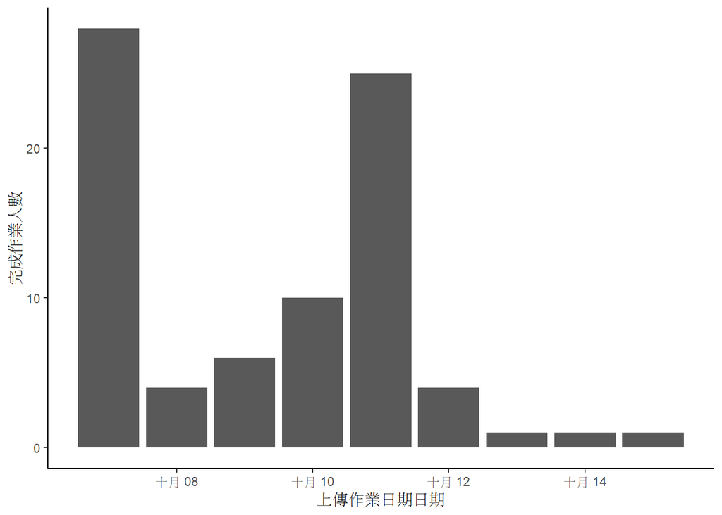

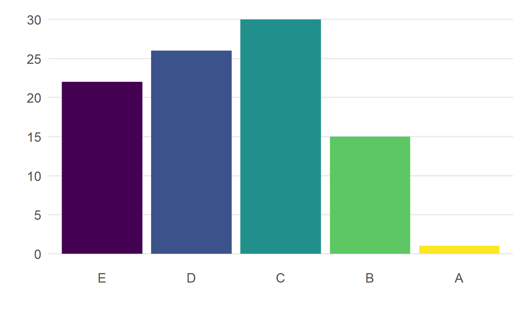

## 檢視個人回饋單

有收到個人評語的同學，只要將個人作業再拉回(git pull)個人的本機端Rstudio，以瀏覽器開啟feedback.html，就能看到教練和組教給的評語。